# Regression_final

## 1.- For Questions 1-6, consider the following:

The data found at http://www.stat.ufl.edu/~winner/data/pgalpga2008.dat consist of season statistics for individual golfers on the United States LPGA and PGA tours. The first column reports each player’s average driving distance in yards. The second column reports the percentage of the player’s drives that finish in the fairway, measuring their accuracy. The third and final column has a 1 to denote a female golfer (on the LPGA tour), and a 2 to denote male golfer (on the PGA tour).

Load these data into R or Excel. In Excel, once you paste the data into a new worksheet, you may need to separate the data into columns using the “Text to Columns” feature under the “Data” menu.

If you wish to separate the LPGA and PGA data, one way in R is to use the subset function:

datF <- subset(dat, FM==1, select=1:2)

where “dat” is the name of the original data set (replace “dat” with whatever you named this data set), “FM” is the name of the third column (replace “FM” with whatever you named this column), and select=1:2 means to include columns 1 and 2 in the new data set “datF”.

```r
golfersF <- subset(golfers, female==1, select=1:2) #female
golfersM <- subset(golfers, female==2, select=1:2) #male
```

Create two scatter plots with average drive distance on the x-axis and percent accuracy on the y-axis, one for female golfers and one for male golfers. What do you observe about the relationship between these two variables?

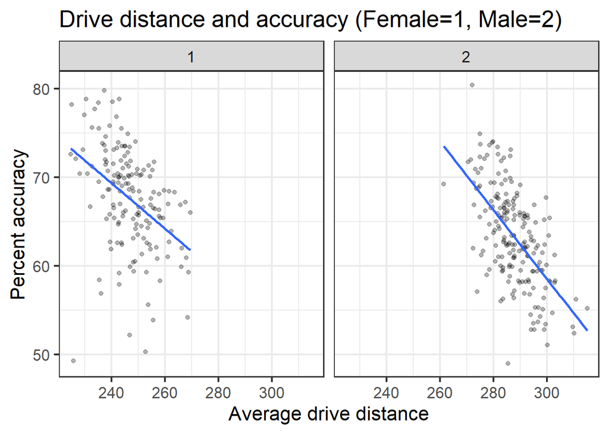

```r
theme_set(theme_bw())
golfers %>%
  ggplot(aes(x=driving_distance,y=accuracy)) +
  geom_point(alpha=0.3) +
  labs(x="Average drive distance", y= "Percent accuracy",
       title="Drive distance and accuracy (Female=1, Male=2)") +
  geom_smooth(method=lm,se=FALSE)+
  facet_wrap(~female, ncol=2)+
  theme_bw(base_size = 16)
```

Drive distance and accuracy are negatively correlated; greater distances are associated with less accuracy.

## 2. Golf:

Fit a linear regression model to the female golfer data only with drive distance as the explanatory variable $x$ and accuracy as the response variable $y$. Use the standard reference (non-informative) prior.

Recall that in a linear regression, we are modeling $E(y)=b_0+b_1x$.

In this particular model, the intercept term is not interpretable, as we would not expect to see a 0-yard drive (but it is still necessary). Predictions should generally be made only within the range of the observed data.

Report the posterior mean estimate of the slope parameter $b$ relating drive distance to accuracy. Round your answer to two decimal places.

```r
golfersF.lm=lm(accuracy~driving_distance, data=golfersF)
summary(golfersF.lm)
```

```
##
## Call:
## lm(formula = accuracy ~ driving_distance, data = golfersF)
##
## Residuals:
##      Min       1Q   Median       3Q      Max
## -23.6777  -2.6583   0.9829   3.6346  10.2339
##
## Coefficients:
##                   Estimate Std. Error t value Pr(>|t|)
## (Intercept)      130.89331   10.92765  11.978  < 2e-16 ***
## driving_distance  -0.25649    0.04424  -5.797 3.66e-08 ***
## ---
## Signif. codes:  0 '***' 0.001 '**' 0.01 '*' 0.05 '.' 0.1 ' ' 1
##
## Residual standard error: 5.246 on 155 degrees of freedom
## Multiple R-squared:  0.1782, Adjusted R-squared:  0.1729
## F-statistic: 33.61 on 1 and 155 DF,  p-value: 3.662e-08
```

Answer: -0.26

## 3. Golf:

The posterior mean estimate of the slope from Question 2 is about five standard errors below 0. Hence, the posterior probability that this slope is negative is near 1.

Suppose the estimate is $b$. How do we interpret this value?

Answer: For each additional yard of driving distance, we expect to see a decrease in percentage accuracy of $|b|$.

## 4.Golf:

Use the posterior mean estimates of the model coefficients to obtain a posterior predictive mean estimate of driving accuracy for a new female golfer whose average driving distance is $x=260$ yards. Round your answer to one decimal place.

Answer: $130.89331-0.25649(260)=64.2$

## 5. Golf:

Which of the following gives a 95% posterior predictive interval for the driving accuracy of a new female golfer whose average driving distance is $x=260$ yards?

Hint: Modify the code provided with this lesson under “prediction interval”.

```r
predict(golfersF.lm,data.frame(driving_distance=260),interval="predict")
```

```
##        fit      lwr      upr
## 1 64.20573 53.74528 74.66619
```

## 6. Golf:

What is the correct interpretation of the interval found in Question 5?

Answer: If we select a new female golfer who averages 260 yards per drive, our probability that her driving accuracy will be in the interval is .95.

## 7.- Golf:

Now consider a multiple regression on the full data set, including both female and male golfers. Modify the third variable to be a 0 if the golfer is female and 1 if the golfer is male and fit the following regression: $E(y)=b_0+b_1x_1+b_2x_2$.

where $x_1$ is the average driving distance and $x_2$ is the indicator that the golfer is male.

What is the posterior mean estimate of $b_0$ ? Round your answer to the nearest whole number.

```r
golfers$female[golfers$female == 1] <- "female"
golfers$female[golfers$female == 2] <- "male"
golfers$female[golfers$female == "female"] <- 0
golfers$female[golfers$female == "male"] <- 1
```

```r
golfers.lm=lm(accuracy~driving_distance+female, data=golfers)
summary(golfers.lm)
```

```
##
## Call:
## lm(formula = accuracy ~ driving_distance + female, data = golfers)
##
## Residuals:
##      Min       1Q   Median       3Q      Max
## -25.0712  -2.8263   0.4867   3.3494  12.0275
##
## Coefficients:
##                   Estimate Std. Error t value Pr(>|t|)
## (Intercept)      147.26894    7.03492  20.934  < 2e-16 ***
## driving_distance  -0.32284    0.02846 -11.343  < 2e-16 ***
## female1            8.94888    1.26984   7.047 9.72e-12 ***
## ---
## Signif. codes:  0 '***' 0.001 '**' 0.01 '*' 0.05 '.' 0.1 ' ' 1
##
## Residual standard error: 4.797 on 351 degrees of freedom
## Multiple R-squared:  0.3589, Adjusted R-squared:  0.3552
## F-statistic: 98.24 on 2 and 351 DF,  p-value: < 2.2e-16
```

Answer: 147

## 8.- Golf data:

The posterior mean estimates of the other two coefficients are $\hat{b}_1=-0.323$ and $\hat{b}_2=8.94$. What is the interpretation of $\hat{b}_1$ ?

Answer: Holding all else constant, each additional yard of distance is associated with a 0.323 decrease in drive accuracy percentage.

## 9.Golf data:

The standard error for $b_1$ (which we can think of as marginal posterior standard deviation in this case) is roughly 1/10 times the magnitude of the posterior mean estimate $\hat{b}_1=-0.323$. In other words, the posterior mean is more than 10 posterior standard deviations from 0. What does this suggest?

Answer: The posterior probability that $b_1<0$ is very high, suggesting a negative relationship between driving distance and accuracy.

## 10.Golf data:

The estimated value of $b_2$ would typically be interpreted to mean that holding all else constant (for a fixed driving distance), golfers on the PGA tour are about 9% more accurate with their drives on average than golfers on the LPGA tour. However, if you explore the data, you will find that the PGA tour golfers’ average drives are 40+ yards longer than LPGA tour golfers’ average drives, and that the LPGA tour golfers are actually more accurate on average. Thus $b_2$, while a vital component of the model, is actually a correction for the discrepancy in driving distances. Although model fitting can be easy (especially with software), interpreting the results requires a thoughtful approach.

It would also be prudent to check that the model fits the data well. One of the primary tools in regression analysis is the residual plot. Residuals are defined as the observed values $y$ minus their predicted values $\hat{y}$. Patterns in the plot of $\hat{y}$ versus residuals, for example, can indicate an inadequacy in the model. These plots are easy to produce: plot(fitted(mod), residuals(mod)), where “mod” is the model object fitted with the lm() command.

Fit the regression and examine the residual plots. Which of the following statements most accurately describes the residual plots for this analysis?

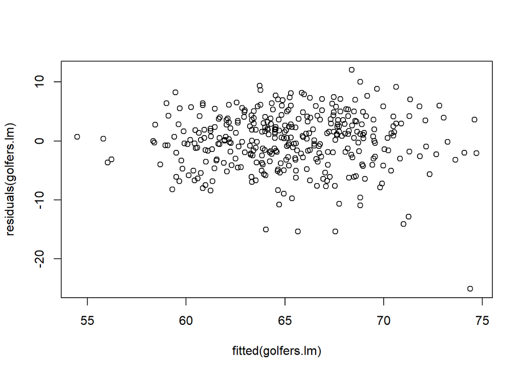

```r
plot(fitted(golfers.lm), residuals(golfers.lm))
```

Answer: The residuals appear to be random and lack any patterns or trends. However, there is at least one outlier (extreme observation) that we may want to investigate.